# Text and Web Mining: **IMDb**

## Data Mining II

*Joel Sousa up201103870*

*Luis Moreira up201102786*

*Pavel Kajaba up201610230*

*Pedro Osório up201102741*

#### Introduction

Over the years a lot of Data has been generated using the world wide web and so, as Computer Scientists, it is our job to manage all this information and, by using some Data Mining skills on Internet Movie Database (IMDb), to perform an exhaustive analysis of this Data in a way that will be helpful to determine whatever movie’s information a common user would like to see after an initial search.

#### Main tasks

1. Find basic information (web page, diretor, cast, etc.) of a movie based on a query string of the title.

   For this specific task our searcher function is getting the following information.
   - Name
   - Description
   - Directors
   - Creators
   - Cast
2. Given the IMDb ID of a movie, obtain the information on all reviews of this movie.
3. Using the reviews information (text of the review plus the score), build a data set for learning a model that can predict the grade based on the text.
4. Using the previous data set try a few prediction models and draw conclusions from this experimental comparison.
5. Summarise the reviews of a movie.

#### Practical Work

##### Searcher function

###### Inital Setup

In this assignment we’ve used the following libraries:

```r
knitr::opts_chunk$set(error = TRUE)
library(rvest)
library(arules)
library(XML)
```

###### Grabbing Movie’s Information

Our first goal was to be able to submit a query on IMDb’s main form. After submitting the query we need to scrape up the html of IMDb and then navigate through each hyperlink on it using the rvest package to get the info of each movie listed on the movie’s result list.

We’ve found a way to set this right: We’ve noticed that by pressing “movies” on the sidebar of the IMDb website, we’re able to restrict the search only for movies, so a lot of misleading results related, for example to TV series, were discarded and so we’re able to reduce our result list. In terms of string matching, the IMDb website is ordering the movies result list by itself using some sort of string score related matchups and so we’re taking advantage over this feature and our list is already ordered by confidence, and in this case our confidence factor is string matching.

Our search fuction is the one presented bellow:

```r
searcher <- function(query,limit) {
  ...
}
```

It’s getting a query as a string and then is going to do the search for You on the IMDb website. Now lets take a look of what’s inside our function: First, We’ve used the following code to perform the IMDb’s form submission to obtain the result list.

```r
searcher <- function(query,limit) {
  ...
type <- "tt"
imdbURL <- "http://www.imdb.com"
movieList <- html_session(imdbURL)
form <- html_form(movieList)[[1]]
form <- set_values(form, q = query, s = type)
response <- submit_form(movieList, form)
responseURL <- response$url
moviesUrlList <- paste(responseURL,"&ttype=ft&ref_=fn_ft",sep = "")
  ...
}
```

We’ve settled a type *“tt”* (that we found it was being used on the form’s html code). Then by using the rvest package we’re able to submit our query and to obtain the URL of the result page and then stored on *moviesUrlList* variable. An example of a movie’s URL from that list is:

*www.imdb.com/title/tt0129387/?ref_=fn_ft_tt_1*

Where *ttxxxxxxx* is the movie ID, so to grab movie’s Name and ID we’ve used the following code.

```r
searcher <- function(query,limit) {
  ...
movName <- read_html(moviesUrlList)
moviesName <- movName %>%
  html_nodes(".result_text") %>%
  html_text(trim=T)

movID <- read_html(moviesUrlList)
moviesID <- movID %>%
  html_nodes(".result_text") %>%
  html_nodes("a") %>%
  html_attr("href")
...
}
```

After having all this information stored properly we’ve done the following procedure to grab movie’s information mencioned above.

Basically what we’re going to do is to create an external file so we can print out all the info and see it properly with any text editor: if that file already exists, we first remove it and then print on it, otherwise we just print on it.

For each movie’s ID stored in *moviesID* list we’ve constructed the URL that points to each movie on our List and then we’re able to navigate through it using rvest. So for each one of those movies we grab the information we need then we print out into the file mencioned above and also we’ve stored that info into a result list named: *queryResult*.

The key factor that really improves our code’s efficient is the *limit* variable: if it’s not present our code will retrieve **all** movie’s information, and this is a slow process if we get like **200 hits**. By using the limit factor we can limit the number of retrieved movies and so the process of retrieving movie’s information will be much quicker.

Here we present the final result as described on the previous sections.

```r
searcher <- function(query,limit) {
 type <- "tt"
  imdbURL <- "http://www.imdb.com"
  movieList <- html_session(imdbURL)
  form <- html_form(movieList)[[1]]
  form <- set_values(form, q = query, s = type)
  response <- submit_form(movieList, form)
  responseURL <- response$url
  moviesUrlList <- paste(responseURL,"&ttype=ft&ref_=fn_ft",sep = "")

  movName <- read_html(moviesUrlList)
  moviesName <- movName %>%
    html_nodes(".result_text") %>%
    html_text(trim=T)
  movID <- read_html(moviesUrlList)
  moviesID <- movID %>%
    html_nodes(".result_text") %>%
    html_nodes("a") %>%
    html_attr("href")

  #Build URL for each movie and get all its info !
  f <- "movies_info.txt"
  if(!file.exists(f)) {
    file.create(f, showWarnings = T)
  } else {
    file.remove(f)
  }
  index <- 1
  queryResult <- c()
  for(id in moviesID) {
    movieURL <- read_html(paste(imdbURL,id,sep = ""))
    #Movie's description
    description <- movieURL %>%
      html_nodes(xpath = '//div[@class="summary_text"]/text()[1]') %>%
      html_text(trim=T)
    #Movie's director
    directors <- movieURL %>%
      html_nodes(xpath = '//span[@itemprop="director"]') %>%
      html_text(trim=T)
    #Movie's creators
    creators <- movieURL %>%
      html_nodes(xpath = '//span[@itemprop="creator"]') %>%
      html_text(trim=T)
    #Movie's cast
    cast <- movieURL %>%
      html_nodes("#titleCast .itemprop span") %>%
      html_text(trim=T)
    #RESULT LIST
    if(!missing(limit)) {
      if(index <= limit) {
        write("NAME", file = f, append = T)
        write(moviesName[index], file = f, append = T)
        write("DESCRIPTION", file = f, append = T)
        write(description, file = f, append = T)
        write("DIRECTORS", file = f, append = T)
        write(directors, file = f, append = T)
        write("CREATORS", file = f, append = T)
        write(creators, file = f, append = T)
        write("CAST", file = f, append = T)
        write(cast, file = f, append = T)
        write("--------------------------", file = f, append = T)
        queryResult[[index]] = list(moviesName[index], description, directors, creators, cast)
      }
      else {
        break
      }
    } else {
      write("NAME", file = f, append = T)
      write(moviesName[index], file = f, append = T)
      write("DESCRIPTION", file = f, append = T)
      write(description, file = f, append = T)
      write("DIRECTORS", file = f, append = T)
      write(directors, file = f, append = T)
      write("CREATORS", file = f, append = T)
      write(creators, file = f, append = T)
      write("CAST", file = f, append = T)
      write(cast, file = f, append = T)
      write("--------------------------", file = f, append = T)
      queryResult[[index]] = list(moviesName[index], description, directors, creators, cast)
    }
    index <- index + 1
  }
  if(!missing(limit)) {
    if(limit > length(queryResult)){
      sprintf("Max limit allowed: %d",length(queryResult))
    } else {
      for(i in 1:limit) {
        print(queryResult[[i]])
      }
    }
  } else {
    print(queryResult)
  }
}
```

To test it out please run this script using the source button on RStudio and then by using the console type some movie that You like:

```r
searcher("Jobs",1)
```

```
## [[1]]
## [1] "Steve Jobs (2015)"
##
## [[2]]
## [1] "Steve Jobs takes us behind the scenes of the digital revolution, to paint a portrait of the man at its epicenter. The story unfolds backstage at three iconic product launches, ending in 1998 with the unveiling of the iMac."
##
## [[3]]
## [1] "Danny Boyle"
##
## [[4]]
## [1] "Aaron Sorkin (screenplay)," "Walter Isaacson (book)"
## [3] "Universal Pictures"         "Legendary Entertainment"
## [5] "Scott Rudin Productions"
##
## [[5]]
##  [1] "Michael Fassbender"  "Kate Winslet"        "Seth Rogen"
##  [4] "Jeff Daniels"        "Michael Stuhlbarg"   "Katherine Waterston"
##  [7] "Perla Haney-Jardine" "Ripley Sobo"         "Makenzie Moss"
## [10] "Sarah Snook"         "John Ortiz"          "Adam Shapiro"
## [13] "John Steen"          "Stan Roth"           "Mihran Slougian"
```

##### Text Mining

###### Initial Setup

In this part of the assignment we’ve defined a fixed query for submitting into IMDb and then retrieve all reviews of that specific movie to perform a Text Mining to determine if that movie was good or bad. First let’s take a look at the inital setup:

```r
knitr::opts_chunk$set(error = TRUE)
library(rvest)
library(arules)
library(XML)
library(dplyr)
library(wordcloud)
library(tm)
source("http://bioconductor.org/biocLite.R")
biocLite("Rgraphviz")
library(Rgraphviz)
```

###### Grabbing Movie’s reviews

First we’re going to set a query and by using the rvest package we can use the same process of the searcher function but this time by focus on user’s reviews.

```r
query<-"tt0120737"
# Store web url
imdbURL <- "http://www.imdb.com/title/"
movieURL<-paste(imdbURL,query,sep="")
movieURL
```

```
## [1] "http://www.imdb.com/title/tt0120737"
```

By using this URL we can start looking for a way to retrieve movie’s reviews. To accomplish this task we’ve tried several different ways but only one seems to work properly: on movie’s reviews page we detect a *count* variable, and if we’re able to set this variable right we could retrieve all those reviews. So to that what’ve done was: first we’ve scraped the main page of that specific movie for getting the value under the rate star, and this value it’s **always** bigger than the *count* variable that was on movie’s reviews page, so if we set the variable with that value, no matter what, the page will **always** retrieve all reviews, so we won’t loose any important reviews, and by doing this we’re able to retrieve all of them so then we could perform a Text Mining.

So first we’ve opened an html session and went after the rating value under the star.

```r
site <- html_session(movieURL)
#Scrape the website for the movie rating
n<- site %>%
  html_node(".imdbRating a") %>%
  html_text(trim=T)
n
```

```
## [1] "1,318,069"
```

As You can see this value was returned as a String and has a lot of commas seperating all these numbers. This next code will parse the entire String and retrive the number we want as a numeric that it should be. And here it is.

```r
aux<-gsub(",", ".", gsub("\\.", "", n))
number_of_reviews<- as.numeric(gsub("\\.","", as.character(aux)))
number_of_reviews
```

```
## [1] 1318069
```

Now let’s construct step by step the URL that we want with that value settled on *count* variable.

```r
reviewsLink <- paste(movieURL,"/reviews?count=",sep="")
reviewsLink2 <- paste(reviewsLink,number_of_reviews,sep="")
reviewsLink3<-  paste(reviewsLink2,"&start=0",sep="")
reviewsLink3
```

```
## [1] "http://www.imdb.com/title/tt0120737/reviews?count=1318069&start=0"
```

Aftet this has been done we could go after those text reviews and rating values. To accomplish this task we’ve wrote the folling code. We’re going to show only one review because there are too many to present in this document, and only eight rating values for the same reason.

```r
#Get Reviews
rev <- read_html(reviewsLink3)
review <- rev %>%
  html_nodes("#tn15content p") %>%
  html_text(trim=T)
review[23]
```

```
## [1] "Minor SpoilersI finally got to see the Lord of the Rings a few days ago in the theatre and\nI must I was very thrilled see a huge movie of this stature. For months I\nwanted to see this because of several reasons but the biggest one of them\nwas Christopher Lee! I knew he was going to be awe…
```

```r
#Get Ratings
rat <- read_html(reviewsLink3)
rating <- rat %>%
  html_nodes(xpath="//div/div/img/@alt") %>%
  html_text(trim=T)
head(rating,8)
```

```
## [1] "10/10" "10/10" "10/10" "10/10" "9/10"  "10/10" "10/10" "10/10"
```

As You can see on our text there are a lot of undesirable characters (‘’,‘n’,etc) and we need to get rid of them. To perform this text cleaning we’re wrote the folling code:

```r
# Text Cleaning
docs <- Corpus(VectorSource(review))
docs <- tm_map(docs, removePunctuation)
docs <- tm_map(docs, removeNumbers)
rem <- function(x) gsub('[[:space:]|[:punct:]]+', ' ', x)
docs <- tm_map(docs, content_transformer(rem))
rem <- function(x) gsub('<[a-z]*>', '', x)
docs <- tm_map(docs, content_transformer(rem))
toSpace <- content_transformer(function (x , pattern ) gsub(pattern, " ", x))
docs <- tm_map(docs, toSpace, "/")
docs <- tm_map(docs, toSpace, "@")
docs <- tm_map(docs, toSpace, "\\|")
docs <- tm_map(docs, toSpace, "<[a-z]*>")
docs <- tm_map(docs, toSpace, "[[a-z0-9]*]")
docs <- tm_map(docs, content_transformer(tolower))
docs <- tm_map(docs, removeWords, stopwords("english"))
docs <- tm_map(docs, stripWhitespace)
docs <- tm_map(docs, stemDocument)
inspect(docs[23])
```

```
## <<SimpleCorpus>>
## Metadata:  corpus specific: 1, document level (indexed): 0
## Content:  documents: 1
##
## [1] minor spoilersi final got see lord ring day ago theatr must thrill see huge movi statur month want see sever reason biggest one christoph lee knew go awesom movi wasthi cast great treat see ian holm aswelli knew lotr go one greatest movi ever just love sceneri movi special effect flawless gre…
```

Some of those words have got distorted but we can still analyse them because important words like ‘good’, ‘bad’, ‘worst’, that usually defines the movie as a good or a bad movie, there’re still there so we can perform our analysis straight away. First we’ve created a matrix that has n rows with all the words tha have been found on user’s reviews. Then for each word we’re going to show the frequency of it.

```r
dtm <- TermDocumentMatrix(docs)
m <- as.matrix(dtm)
v <- sort(rowSums(m),decreasing=TRUE)
d <- data.frame(word = names(v),freq=v)
head(d,20)
```

```
##            word  freq
## movi       movi 15272
## film       film 10683
## book       book  7418
## ring       ring  5827
## one         one  5258
## see         see  4520
## like       like  4507
## time       time  4225
## charact charact  3859
## just       just  3677
## stori     stori  3631
## read       read  3606
## jackson jackson  3497
## will       will  3425
## good       good  3385
## great     great  3149
## make       make  2719
## tolkien tolkien  2698
## scene     scene  2697
## best       best  2634
```

In our top 20 most used words we can find words like **good**, **great** and **best**. All these are a good indicative of a good movie, but let’s do some word correlation and try to find what they realy mean. First we’re going to present our wordcloud plot.

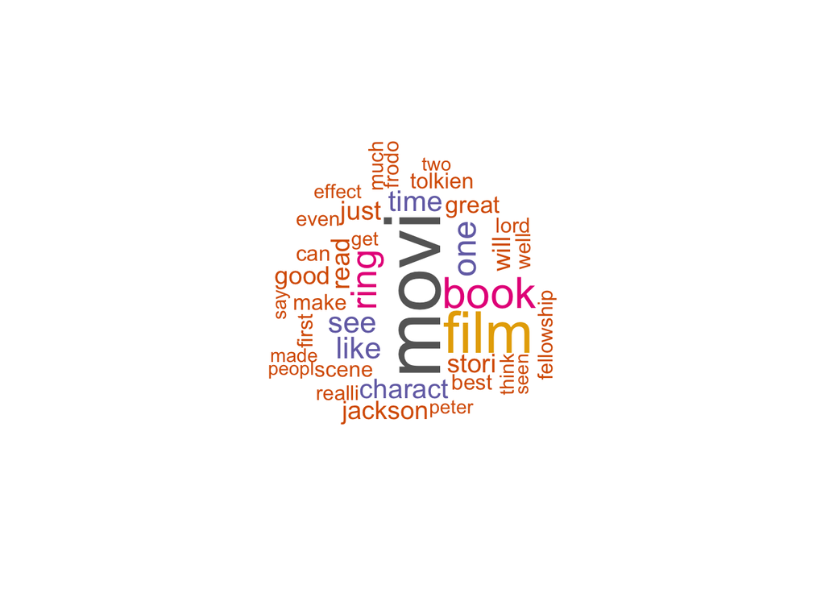

```r
set.seed(1234)
wordcloud(words = d$word, freq = d$freq, min.freq = 2000, max.words=200, random.order=FALSE, rot.per=0.35, colors=brewer.pal(8, "Dark2"))
```

Wen can see on this plot some of the words that we’ve mencioned above. So now let’s do some word correlation. Let’s try for example the word **good** (that is present on our plot).

```r
findAssocs(dtm, terms = "good", corlimit = 0.3)
```

```
## $good
## like
## 0.32
```

It’s correlated to the word “like”. But maybe that’s not to much information to say that this is actually a good movie. So we’ve tried the word **great** (that is also present on our plot). Usually when we use “great” it’s beacause we want to describe something as “great”, so let’s find out what is that.

```r
findAssocs(dtm, terms = "great", corlimit = 0.3)
```

```
## $great
## numeric(0)
```

No results were found so we’ve low down the *corlimit* value to **0.2**.

```r
findAssocs(dtm, terms = "great", corlimit = 0.2)
```

```
## $great
##    movi    also     one charact    make    ring   stori    film  realli
##    0.27    0.23    0.23    0.22    0.21    0.21    0.21    0.21    0.20
```

On top of those words there it is: **movi** also known as **movie**! So now we have a possible set of this movie’s rate.

1. great movie
2. great story
3. great film

We’ve done only one wordcloud because of one reason: we’ve tested quite a lot of movies and all of them have different rating’s and reviews’s length, so both arrays had different lengths and because of that we’ve decided to choose a good movie and proove that by using web and text mining we could define this as movie as good. We’ve also tried an example of a bad movie and actually the result was bad as well.

In order to better visualize the text mining/analysis we’ve done some statistcal work including to create some charts so it becames easier to understand our text mining. So by using the previous dataframe (that includes all words used by users, and each word has a frequency value settled) we’ve created a bar plot that shows the top 20 most common words in all reviews. Then we’re going to present a graph that shows all word’s correlation but to show only the most important ones we’ve settled the *correlation factor* to **0.27**.

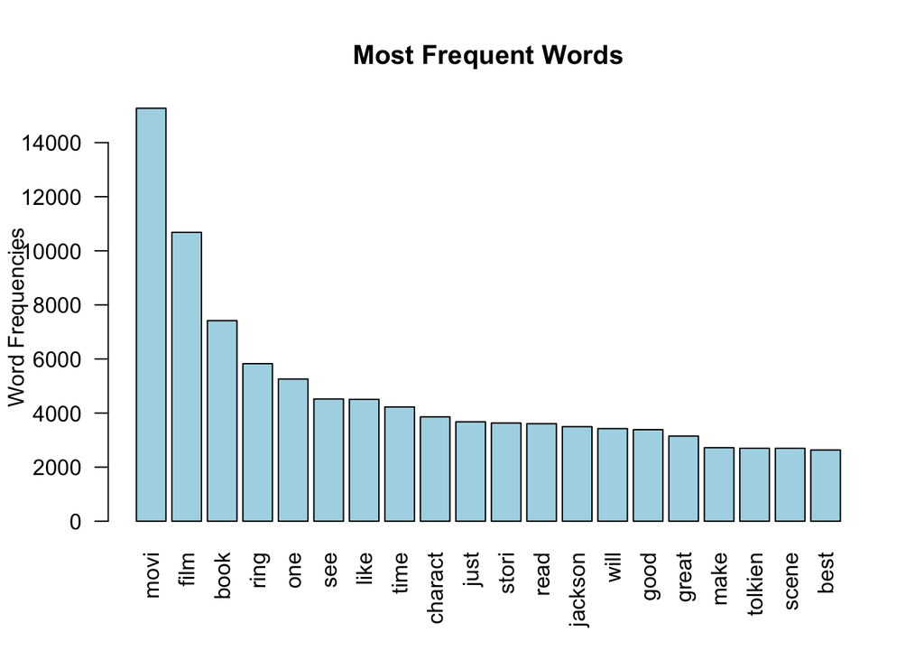

```r
barplot(d[1:20,]$freq, las = 2, names.arg = d[1:20,]$word,
        col ="lightblue", main ="Most Frequent Words",
        ylab = "Word Frequencies")
```

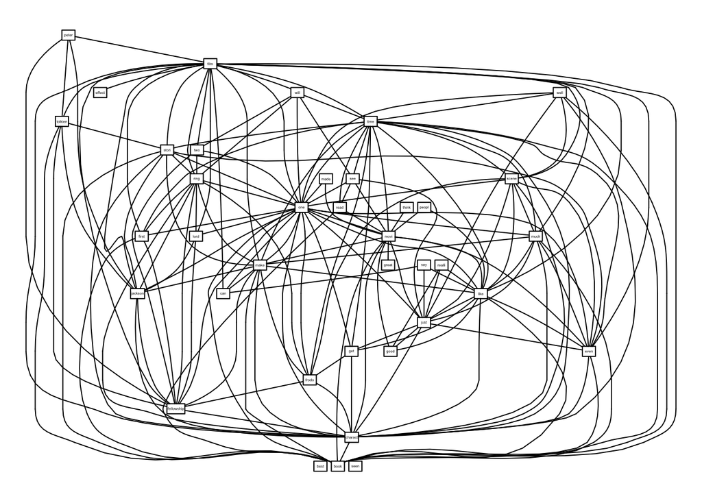

```r
freq.terms <- findFreqTerms(dtm, lowfreq = 2000)
term.freq <- rowSums(as.matrix(dtm))
term.freq <- subset(term.freq, term.freq >= 2000)
df <- data.frame(term = names(term.freq), freq = term.freq)
plot(dtm, term = freq.terms, corThreshold = 0.27, weighting = F)
```

On this graph if we look closer we can see a connection between **movi** and **great** as we’ve shown before.

#### Conclusion

During this assignment, considering what we’ve done, we’ve used a lot of both text and web mining and we’ve learned how to process data in order to retrieve pernitent information as for exemple by telling if some movie, book or whatever is good or bad by using theses tools that text and web mining provide us.

We hope that our work presented here is clearly and self-explanatory so every detail left no doubts.